# Práctica 2. Tipología y ciclo de vida de los datos.

Autores: Marc Lluis, Orlando Belloch

Enero 2021

# 1 Práctica 2

## 1.1 Descripción del dataset

El dataset utilizado en esta práctica es “Avocado Prices”. Este dataset almacena valores históricos sobre el precio de los aguacates y el volumen de ventas en varios supermercados de Estados Unidos. Se ha obtenido desde la plataforma web Kaggle. Para acceder se puede utilizar este [enlace](https://www.kaggle.com/neuromusic/avocado-prices).

El dataset está compuesto de 14 columnas descritas a continuación:

- X - Numeración.
- Date - Fecha de la observación.
- AveragePrice - Precio medio de un aguacate.
- type - convencional u orgánico.
- year - Año.
- Region - Ciudad o región.
- Total Volume - Número total de aguacates vendidos.
- X4046 - Número de aguacates PLU 4046 vendidos.
- X4225 - Número de aguacates PLU 4225 vendidos.
- X4770 - Número de aguacates PLU 4770 vendidos.
- Total.Bags - Numero total de bolsas.
- Small.Bags - Número total de bolsas pequeñas.
- Large.Bags - Número total de bolsas grandes.
- XLarge.Bags - Número total de bolsas muy grandes.

Este dataset es importante a la hora de evaluar la influencia que tienen aspectos como el tipo de aguacate, la región o el tipo de bolsa utilizada, en el precio final del producto y el número de ventas. El problema que se pretende resolver es averiguar la relación que existe entre estos atributos con el objetivo de predecir el número de ventas o el precio del aguacate en un futuro.

## 1.2 Integración y selección de los datos de interés a analizar.

```r
# Carga de las librerías necesarias y lectura del archivo .csv
library(dplyr)
```

```r
library(ggplot2)
data <- read.csv("avocado.csv", header=TRUE, sep=",")
```

A continuación, comprobamos las dimensiones del dataset. Podemos observar que el dataframe obtenido está compuesto por 14 variables y más de 18.000 filas.

```r
dim(data)
```

```
## [1] 18249    14
```

```r
numFilas = dim(data)[1]
numCols = dim(data)[2]
```

Con las funciones str() y summary() observamos aspectos como el tipo de variable, los cuartiles, la media o la mediana. También podemos observar que el tipo de algunas variables no es ideal:

- Date - Debería ser el tipo fecha (Date)
- Region - Se podría indicar a modo de factor para que sea más facil su análisis.
- Type - Tipo factor para facilitar su análisis.

```r
str(data)
```

```
## 'data.frame':    18249 obs. of  14 variables:
##  $ X           : int  0 1 2 3 4 5 6 7 8 9 ...
##  $ Date        : chr  "2015-12-27" "2015-12-20" "2015-12-13" "2015-12-06" ...
##  $ AveragePrice: num  1.33 1.35 0.93 1.08 1.28 1.26 0.99 0.98 1.02 1.07 ...
##  $ Total.Volume: num  64237 54877 118220 78992 51040 ...
##  $ X4046       : num  1037 674 795 1132 941 ...
##  $ X4225       : num  54455 44639 109150 71976 43838 ...
##  $ X4770       : num  48.2 58.3 130.5 72.6 75.8 ...
##  $ Total.Bags  : num  8697 9506 8145 5811 6184 ...
##  $ Small.Bags  : num  8604 9408 8042 5677 5986 ...
##  $ Large.Bags  : num  93.2 97.5 103.1 133.8 197.7 ...
##  $ XLarge.Bags : num  0 0 0 0 0 0 0 0 0 0 ...
##  $ type        : chr  "conventional" "conventional" "conventional" "conventional" ...
##  $ year        : int  2015 2015 2015 2015 2015 2015 2015 2015 2015 2015 ...
##  $ region      : chr  "Albany" "Albany" "Albany" "Albany" ...
```

```r
summary(data)
```

```
##        X             Date            AveragePrice    Total.Volume
##  Min.   : 0.00   Length:18249       Min.   :0.440   Min.   :      85
##  1st Qu.:10.00   Class :character   1st Qu.:1.100   1st Qu.:   10839
##  Median :24.00   Mode  :character   Median :1.370   Median :  107377
##  Mean   :24.23                      Mean   :1.406   Mean   :  850644
##  3rd Qu.:38.00                      3rd Qu.:1.660   3rd Qu.:  432962
##  Max.   :52.00                      Max.   :3.250   Max.   :62505647
##      X4046              X4225              X4770           Total.Bags
##  Min.   :       0   Min.   :       0   Min.   :      0   Min.   :       0
##  1st Qu.:     854   1st Qu.:    3009   1st Qu.:      0   1st Qu.:    5089
##  Median :    8645   Median :   29061   Median :    185   Median :   39744
##  Mean   :  293008   Mean   :  295155   Mean   :  22840   Mean   :  239639
##  3rd Qu.:  111020   3rd Qu.:  150207   3rd Qu.:   6243   3rd Qu.:  110783
##  Max.   :22743616   Max.   :20470573   Max.   :2546439   Max.   :19373134
##    Small.Bags         Large.Bags       XLarge.Bags           type
##  Min.   :       0   Min.   :      0   Min.   :     0.0   Length:18249
##  1st Qu.:    2849   1st Qu.:    127   1st Qu.:     0.0   Class :character
##  Median :   26363   Median :   2648   Median :     0.0   Mode  :character
##  Mean   :  182195   Mean   :  54338   Mean   :  3106.4
##  3rd Qu.:   83338   3rd Qu.:  22029   3rd Qu.:   132.5
##  Max.   :13384587   Max.   :5719097   Max.   :551693.7
##       year         region
##  Min.   :2015   Length:18249
##  1st Qu.:2015   Class :character
##  Median :2016   Mode  :character
##  Mean   :2016
##  3rd Qu.:2017
##  Max.   :2018
```

### 1.2.1 Transformaciones.

Tal y como se ha indicado en el apartado anterior, transformamos las variables type y region en factores para poder trabajar mejor con ellas.

```r
data$type <- as.factor(data$type)
data$region <- as.factor(data$region)
```

El resultado de esta transformación lo podemos observar a continuación:

```r
summary(data$region)
```

```
##              Albany             Atlanta BaltimoreWashington               Boise
##                 338                 338                 338                 338
##              Boston    BuffaloRochester          California           Charlotte
##                 338                 338                 338                 338
##             Chicago    CincinnatiDayton            Columbus       DallasFtWorth
##                 338                 338                 338                 338
##              Denver             Detroit         GrandRapids          GreatLakes
##                 338                 338                 338                 338
##  HarrisburgScranton HartfordSpringfield             Houston        Indianapolis
##                 338                 338                 338                 338
##        Jacksonville            LasVegas          LosAngeles          Louisville
##                 338                 338                 338                 338
##   MiamiFtLauderdale            Midsouth           Nashville    NewOrleansMobile
##                 338                 338                 338                 338
##             NewYork           Northeast  NorthernNewEngland             Orlando
##                 338                 338                 338                 338
##        Philadelphia       PhoenixTucson          Pittsburgh              Plains
##                 338                 338                 338                 338
##            Portland   RaleighGreensboro     RichmondNorfolk             Roanoke
##                 338                 338                 338                 338
##          Sacramento            SanDiego        SanFrancisco             Seattle
##                 338                 338                 338                 338
##       SouthCarolina        SouthCentral           Southeast             Spokane
##                 338                 338                 338                 338
##             StLouis            Syracuse               Tampa             TotalUS
##                 338                 338                 338                 338
##                West    WestTexNewMexico
##                 338                 335
```

```r
summary(data$type)
```

```
## conventional      organic
##         9126         9123
```

Transformamos también la variable Date del tipo character a Date. Además, creamos una nueva variable Month para visualizar mejor la evolución en los distintos meses.

```r
fechas <- as.Date(data$Date, format="%Y-%m-%d")
data$Date <- fechas
data$Month <- format(fechas, format="%m")
```

```r
head(data$Month)
```

```
## [1] "12" "12" "12" "12" "11" "11"
```

El resultado de ambas transformaciones lo podemos observar a continuación:

```r
summary(data)
```

```
##        X              Date             AveragePrice    Total.Volume
##  Min.   : 0.00   Min.   :2015-01-04   Min.   :0.440   Min.   :      85
##  1st Qu.:10.00   1st Qu.:2015-10-25   1st Qu.:1.100   1st Qu.:   10839
##  Median :24.00   Median :2016-08-14   Median :1.370   Median :  107377
##  Mean   :24.23   Mean   :2016-08-13   Mean   :1.406   Mean   :  850644
##  3rd Qu.:38.00   3rd Qu.:2017-06-04   3rd Qu.:1.660   3rd Qu.:  432962
##  Max.   :52.00   Max.   :2018-03-25   Max.   :3.250   Max.   :62505647
##
##      X4046              X4225              X4770           Total.Bags
##  Min.   :       0   Min.   :       0   Min.   :      0   Min.   :       0
##  1st Qu.:     854   1st Qu.:    3009   1st Qu.:      0   1st Qu.:    5089
##  Median :    8645   Median :   29061   Median :    185   Median :   39744
##  Mean   :  293008   Mean   :  295155   Mean   :  22840   Mean   :  239639
##  3rd Qu.:  111020   3rd Qu.:  150207   3rd Qu.:   6243   3rd Qu.:  110783
##  Max.   :22743616   Max.   :20470573   Max.   :2546439   Max.   :19373134
##
##    Small.Bags         Large.Bags       XLarge.Bags                 type
##  Min.   :       0   Min.   :      0   Min.   :     0.0   conventional:9126
##  1st Qu.:    2849   1st Qu.:    127   1st Qu.:     0.0   organic     :9123
##  Median :   26363   Median :   2648   Median :     0.0
##  Mean   :  182195   Mean   :  54338   Mean   :  3106.4
##  3rd Qu.:   83338   3rd Qu.:  22029   3rd Qu.:   132.5
##  Max.   :13384587   Max.   :5719097   Max.   :551693.7
##
##       year                      region         Month
##  Min.   :2015   Albany             :  338   Length:18249
##  1st Qu.:2015   Atlanta            :  338   Class :character
##  Median :2016   BaltimoreWashington:  338   Mode  :character
##  Mean   :2016   Boise              :  338
##  3rd Qu.:2017   Boston             :  338
##  Max.   :2018   BuffaloRochester   :  338
##                 (Other)            :16221
```

Por último, eliminamos la variable X debido a que no ofrecía ninguna información relevante.

```r
data <- select(data, -X,)
```

Después de este tratamiento de los datos, se ha observado como hay una gran cantidad de XLarge.Bags con 0, es por ello que es necesario revisar en el siguiente apartado (Limpieza de los datos) si hay algún problema con dicha variable.

```r
summary(data$XLarge.Bags)
```

```
##     Min.  1st Qu.   Median     Mean  3rd Qu.     Max.
##      0.0      0.0      0.0   3106.4    132.5 551693.7
```

## 1.3 Limpieza de los datos

Empezamos este apartado analizando el comportamiento de la variable XLarge.Bags mencionado anteriormente. Con el siguiente boxplot, se puede visualizar que casi todos los datos se encuentran entre el 0 y el 300.

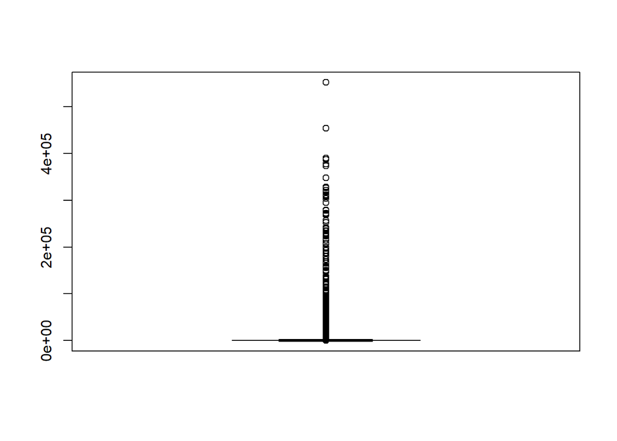

```r
boxplot(data$XLarge.Bags, notch = TRUE)
```

Ordenando los datos de mayor a menor valor de XLarge.Bags se aprecia como el atributo “Region” es igual a “TotalUS” para valores muy grandes de XLarge.Bags. Decidimos eliminar todos los registros cuando region=“TotalUS” debido a que no se puede comparar correctamente los valores relacionados con todo un país (Estados Unidos) con los valores relacionados con un solo estado.

```r
datos <- arrange(data, -XLarge.Bags)
head(datos,50)
```

```
##          Date AveragePrice Total.Volume    X4046    X4225     X4770 Total.Bags
## 1  2016-07-03         1.06     39993186 12508937 13315901 1761343.1   12407004
## 2  2016-07-10         1.10     35567568 11457080 11677528 1266434.0   11166526
## 3  2016-07-17         1.15     32656124 10320463 10628873  953631.5   10753156
## 4  2016-07-24         1.20     32339377 10331314 10795751  947964.1   10264348
## 5  2017-07-02         1.21     38010426 12623189 10988735  859889.8   13538613
## 6  2017-07-09         1.17     39367336 13009944 11031218  821964.4   14504209
## 7  2017-06-18         1.18     38247669 12975373 11199449  807107.2   13265740
## 8  2016-06-26         1.04     36617024 12189035 12029919 1624942.4   10773128
## 9  2017-07-16         1.33     32455047 11155466 11202845  756103.1    9340633
## 10 2016-06-05         0.97     40231260 13808859 13396652 1770948.1   11254801
## 11 2017-08-06         1.33     32529920 11292580 10988314  665312.6    9583714
## 12 2016-06-19         1.02     38489936 13488852 12842698 1642735.6   10515651
## 13 2016-06-12         1.04     35580820 12291687 11533970 1607344.1   10147819
## 14 2018-03-25         1.03     43409836 14130799 12125711  758801.1   16394524
```

[output cut: 87 more lines]

Con el siguiente código, se eliminan las filas donde se incluye TotalUS

```r
data <- data[data$region != "TotalUS",]
summary(data$region)
```

```
##              Albany             Atlanta BaltimoreWashington               Boise
##                 338                 338                 338                 338
##              Boston    BuffaloRochester          California           Charlotte
##                 338                 338                 338                 338
##             Chicago    CincinnatiDayton            Columbus       DallasFtWorth
##                 338                 338                 338                 338
##              Denver             Detroit         GrandRapids          GreatLakes
##                 338                 338                 338                 338
##  HarrisburgScranton HartfordSpringfield             Houston        Indianapolis
##                 338                 338                 338                 338
##        Jacksonville            LasVegas          LosAngeles          Louisville
##                 338                 338                 338                 338
##   MiamiFtLauderdale            Midsouth           Nashville    NewOrleansMobile
##                 338                 338                 338                 338
##             NewYork           Northeast  NorthernNewEngland             Orlando
##                 338                 338                 338                 338
##        Philadelphia       PhoenixTucson          Pittsburgh              Plains
##                 338                 338                 338                 338
##            Portland   RaleighGreensboro     RichmondNorfolk             Roanoke
##                 338                 338                 338                 338
##          Sacramento            SanDiego        SanFrancisco             Seattle
##                 338                 338                 338                 338
##       SouthCarolina        SouthCentral           Southeast             Spokane
##                 338                 338                 338                 338
##             StLouis            Syracuse               Tampa             TotalUS
##                 338                 338                 338                   0
##                West    WestTexNewMexico
##                 338                 335
```

Volvemos a mostrar los datos ordenador de mayor a menor en función del valor de XLarge.Bags. Vemos ahora que todos los valores se corresponden con un único estado.

```r
datos <- arrange(data, -XLarge.Bags)
head(datos,50)
```

```
##          Date AveragePrice Total.Volume     X4046     X4225     X4770
## 1  2018-02-04         0.81      7094765 1410647.9 2875747.9 667141.61
## 2  2016-01-03         0.92      4065583  604697.3 2200074.8 543717.88
## 3  2016-02-07         0.85      4865296  652666.4 2644419.0 704466.56
## 4  2015-12-20         0.81      4565208 2166801.0 1226508.9 412828.75
## 5  2016-07-03         0.91      6494533 3114586.8 1226469.5 522836.75
## 6  2016-07-03         1.13      4020725  574425.9 1781703.5 367119.34
## 7  2016-01-31         0.79      5850128 3003442.8 1462783.1 521213.33
## 8  2016-07-10         1.24      3327062  478536.7 1500516.9 328564.87
## 9  2018-01-21         1.08      4824586  939693.9 1678615.7 599358.14
## 10 2018-02-25         1.19      3920644  663042.8 1184035.0 408305.47
## 11 2018-03-25         1.18      4245947  860997.5 1144066.2 459002.28
## 12 2016-06-19         1.10      3955099  608467.5 1766243.3 431784.45
## 13 2017-02-26         1.08      3848716  565282.8 1692494.9 368973.25
## 14 2016-07-17         1.25      3267858  429390.4 1441657.6 291136.56
```

[output cut: 138 more lines]

A continuación, ordenamos los valores de XLarge.Bags de menor a mayor. Comprobamos en el resultado que puede existir una relación con el tipo de aguacate y con la region. Cuando el aguacate es de tipo convencional y la region es Albany no se venden bolsas XLarge. En base a esta posible relación se decide conservar los valores de XLarge.Bags iguales a cero.

```r
datos <- arrange(data, XLarge.Bags)
head(datos,20)
```

```
##          Date AveragePrice Total.Volume   X4046     X4225  X4770 Total.Bags
## 1  2015-12-27         1.33     64236.62 1036.74  54454.85  48.16    8696.87
## 2  2015-12-20         1.35     54876.98  674.28  44638.81  58.33    9505.56
## 3  2015-12-13         0.93    118220.22  794.70 109149.67 130.50    8145.35
## 4  2015-12-06         1.08     78992.15 1132.00  71976.41  72.58    5811.16
## 5  2015-11-29         1.28     51039.60  941.48  43838.39  75.78    6183.95
## 6  2015-11-22         1.26     55979.78 1184.27  48067.99  43.61    6683.91
## 7  2015-11-15         0.99     83453.76 1368.92  73672.72  93.26    8318.86
## 8  2015-11-08         0.98    109428.33  703.75 101815.36  80.00    6829.22
## 9  2015-11-01         1.02     99811.42 1022.15  87315.57  85.34   11388.36
## 10 2015-10-25         1.07     74338.76  842.40  64757.44 113.00    8625.92
## 11 2015-10-18         1.12     84843.44  924.86  75595.85 117.07    8205.66
## 12 2015-10-11         1.28     64489.17 1582.03  52677.92 105.32   10123.90
## 13 2015-10-04         1.31     61007.10 2268.32  49880.67 101.36    8756.75
## 14 2015-09-27         0.99    106803.39 1204.88  99409.21 154.84    6034.46
```

[output cut: 27 more lines]

Analizamos también los ceros correspondientes al atributo TotalBags. Después de ordenar los datos de menor a mayor valor de “Total.Bags”, observamos que puede existir una relación con el tipo de aguacate. Cuando este es orgánico los aguacates se venden sin bolsa, independientemente de su tamaño. Por este motivo conservamos los registros cuando el número de bolsas es cero.

```r
datos <- arrange(data, Total.Bags)
head(datos,20)
```

```
##          Date AveragePrice Total.Volume    X4046    X4225  X4770 Total.Bags
## 1  2015-05-03         2.03      3976.19  1325.62  2650.57   0.00       0.00
## 2  2015-06-28         1.53     41116.32  7314.21 33780.38  21.73       0.00
## 3  2015-10-18         2.79     12642.11   961.55 11680.56   0.00       0.00
## 4  2015-10-11         2.66     14031.73  1046.84 12984.89   0.00       0.00
## 5  2015-07-19         2.36     19558.81  3893.65 15665.16   0.00       0.00
## 6  2015-04-12         1.54     28220.45 18887.66  9332.79   0.00       0.00
## 7  2015-04-05         1.55     26530.70 17104.69  9426.01   0.00       0.00
## 8  2015-07-05         1.98     29929.57  8841.34 20807.76 280.47       0.00
## 9  2015-06-28         1.71     46229.47  8112.46 37972.31 144.70       0.00
## 10 2015-07-12         2.07      2786.45   680.60  2105.85   0.00       0.00
## 11 2015-07-05         1.85      3162.45   799.67  2362.78   0.00       0.00
## 12 2015-06-28         1.61      4088.37   537.84  3550.53   0.00       0.00
## 13 2015-06-21         1.59      4436.79   872.72  3564.07   0.00       0.00
## 14 2015-02-22         1.41      4655.86  2067.41  2588.45   0.00       0.00
```

[output cut: 27 more lines]

Finalizamos este apartado comprobando si existen variables vacías en otros atributos del dataset.

En las dos variables de tipo factor, gracias a la función unique() podemos confirmar que no hay ningún elemento diferente a lo que se había observado en un primer análisis visual del csv. La función unique() nos permite ver todos los valores que toma una variable.

```r
unique(data$type)
```

```
## [1] conventional organic
## Levels: conventional organic
```

```r
unique(data$region)
```

```
##  [1] Albany              Atlanta             BaltimoreWashington
##  [4] Boise               Boston              BuffaloRochester
##  [7] California          Charlotte           Chicago
## [10] CincinnatiDayton    Columbus            DallasFtWorth
## [13] Denver              Detroit             GrandRapids
## [16] GreatLakes          HarrisburgScranton  HartfordSpringfield
## [19] Houston             Indianapolis        Jacksonville
## [22] LasVegas            LosAngeles          Louisville
## [25] MiamiFtLauderdale   Midsouth            Nashville
## [28] NewOrleansMobile    NewYork             Northeast
## [31] NorthernNewEngland  Orlando             Philadelphia
## [34] PhoenixTucson       Pittsburgh          Plains
## [37] Portland            RaleighGreensboro   RichmondNorfolk
## [40] Roanoke             Sacramento          SanDiego
## [43] SanFrancisco        Seattle             SouthCarolina
## [46] SouthCentral        Southeast           Spokane
## [49] StLouis             Syracuse            Tampa
## [52] West                WestTexNewMexico
## 54 Levels: Albany Atlanta BaltimoreWashington Boise Boston ... WestTexNewMexico
```

Además, con la función is.na() comprobamos que en ninguna de las otras variables hay NAs:

```r
colSums(is.na(data))
```

```
##         Date AveragePrice Total.Volume        X4046        X4225        X4770
##            0            0            0            0            0            0
##   Total.Bags   Small.Bags   Large.Bags  XLarge.Bags         type         year
##            0            0            0            0            0            0
##       region        Month
##            0            0
```

## 1.4 Análisis de los datos.

### 1.4.1 Selección de los grupos

En este caso, seria interesante ver algunas observaciones como por ejemplo:

- La diferencia de precio y su evolucion entre los aguacates convencionales y los organicos.
- Si hay diferencia entre la compra de bolsas entre los aguantes de convencionales y organicos.
- Evolucion en la compra de los aguacates.

### 1.4.2 Comprobación de la normalidad y homogeneidad de la varianza

A continuacion, comprobaremos si las variables numericas tienden a la normalidad. Para ello, utilizaremos el test de Kolomogorv-Smirnov. Concretamente, se utiliza el test Lilliefors, este test asume que la media y varianza son desconocidas, estando especialmente desarrollado para contrastar la normalidad. Es la alternativa al test de Shapiro-Wilk cuando el número de observaciones es mayor de 50.

```r
library("nortest")
numeric_attr <- dplyr::select_if(data, is.numeric)
lapply(numeric_attr, lillie.test)
```

```
## $AveragePrice
##
##  Lilliefors (Kolmogorov-Smirnov) normality test
##
## data:  X[[i]]
## D = 0.051752, p-value < 2.2e-16
##
##
## $Total.Volume
##
##  Lilliefors (Kolmogorov-Smirnov) normality test
##
## data:  X[[i]]
## D = 0.32986, p-value < 2.2e-16
##
##
## $X4046
##
##  Lilliefors (Kolmogorov-Smirnov) normality test
##
## data:  X[[i]]
## D = 0.36061, p-value < 2.2e-16
##
##
## $X4225
##
##  Lilliefors (Kolmogorov-Smirnov) normality test
##
## data:  X[[i]]
## D = 0.33855, p-value < 2.2e-16
##
##
## $X4770
##
##  Lilliefors (Kolmogorov-Smirnov) normality test
##
## data:  X[[i]]
## D = 0.38282, p-value < 2.2e-16
##
##
```

[output cut: 23 more lines]

```
##
## $XLarge.Bags
##
##  Lilliefors (Kolmogorov-Smirnov) normality test
##
## data:  X[[i]]
## D = 0.40505, p-value < 2.2e-16
##
##
## $year
##
##  Lilliefors (Kolmogorov-Smirnov) normality test
##
## data:  X[[i]]
## D = 0.20225, p-value < 2.2e-16
```

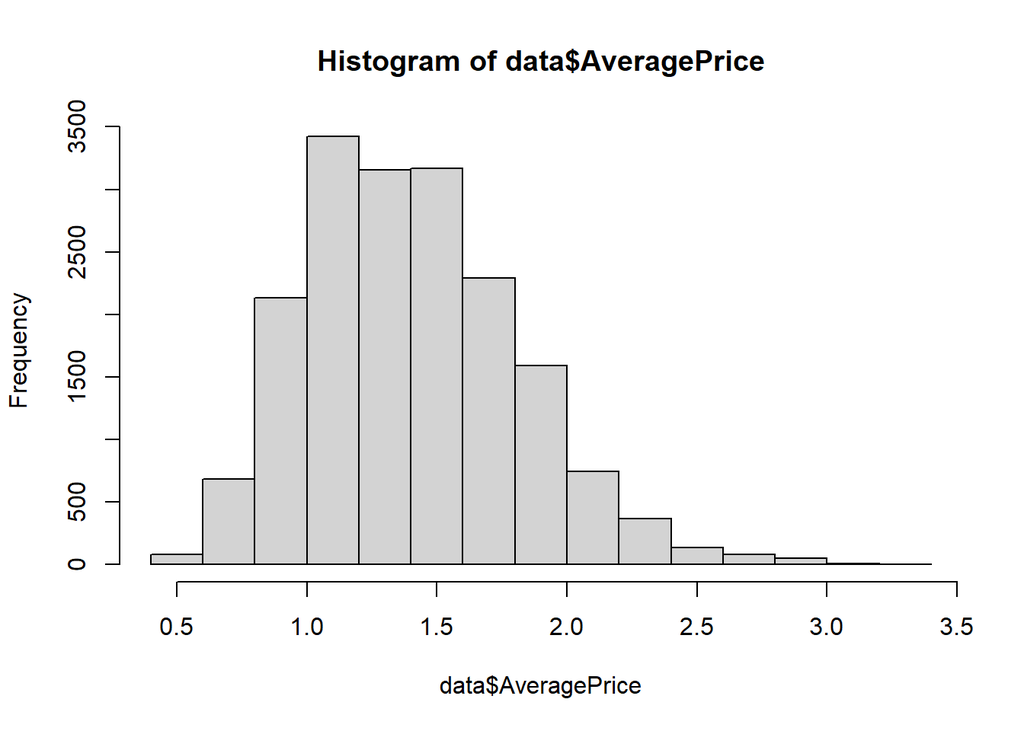

```r
hist(data$AveragePrice)
```

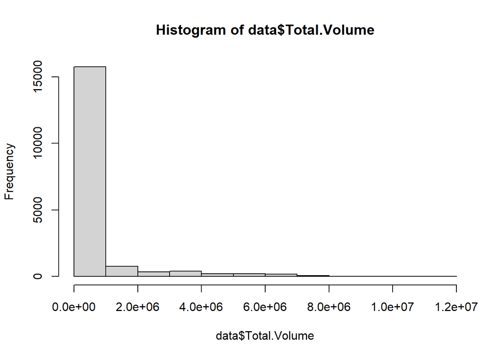

```r
hist(data$Total.Volume)
```

En un primer momento, comparamos las varianzas de las variables del numero de bolsas respecto a los aguacates organicos y convencionales.

```r
a <- data[data$type == "conventional", "Total.Bags"]
b <- data[data$type == "organic", "Total.Bags"]
var.test(a,b)
```

```
##
##  F test to compare two variances
##
## data:  a and b
## F = 247.05, num df = 8956, denom df = 8953, p-value < 2.2e-16
## alternative hypothesis: true ratio of variances is not equal to 1
## 95 percent confidence interval:
##  237.0210 257.4957
## sample estimates:
## ratio of variances
##           247.0463
```

Observamos, con un pvalue practicamente a 0, que las varianzas son diferentes. Esto se puede observar realizando un boxplot:

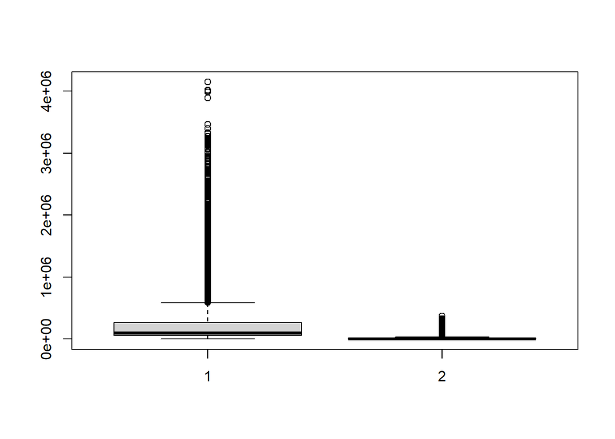

```r
boxplot(a, b)
```

En el caso del precio medio, tambien hay una diferencia en las varianzas:

```r
a <- data[data$type == "conventional", "AveragePrice"]
b <- data[data$type == "organic", "AveragePrice"]
var.test(a,b)
```

```
##
##  F test to compare two variances
##
## data:  a and b
## F = 0.52266, num df = 8956, denom df = 8953, p-value < 2.2e-16
## alternative hypothesis: true ratio of variances is not equal to 1
## 95 percent confidence interval:
##  0.5014455 0.5447621
## sample estimates:
## ratio of variances
##          0.5226553
```

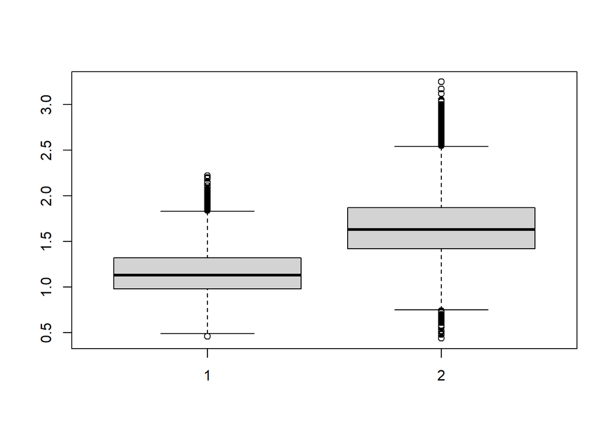

```r
boxplot(a, b)
```

### 1.4.3 Aplicación de pruebas estadísticas para comparar los grupos de datos.

#### 1.4.3.1 Prueba de Contrastes de hipotesis.

En este caso, podemos indicar que las varianzas de las variables Precio Medio respecto a los diferentos tipos de aguacate son diferentes. Por ello, realizaremos la siguiente hipotesis:

La primera hipotesis es que las ventas de aguacates convencionales es la misma que la de organicos:

$$Ho: uCon = uOrg$$

$$H1: ucon > uOrg$$

Observamos que las varianzas son diferentes en las ventas:

```r
var.test( data$Total.Volume[data$type=="conventional"], data$Total.Volume[data$type=="organic"] )
```

```
##
##  F test to compare two variances
##
## data:  data$Total.Volume[data$type == "conventional"] and data$Total.Volume[data$type == "organic"]
## F = 925.84, num df = 8956, denom df = 8953, p-value < 2.2e-16
## alternative hypothesis: true ratio of variances is not equal to 1
## 95 percent confidence interval:
##  888.2691 965.0009
## sample estimates:
## ratio of variances
##           925.8405
```

Para ver la hipotesis realizamos el t.test

```r
t.test( data$Total.Volume[data$type=="conventional"], data$Total.Volume[data$type=="organic"], var.equal=FALSE, alternative = "greater")
```

```
##
##  Welch Two Sample t-test
##
## data:  data$Total.Volume[data$type == "conventional"] and data$Total.Volume[data$type == "organic"]
## t = 61.145, df = 8975.4, p-value < 2.2e-16
## alternative hypothesis: true difference in means is greater than 0
## 95 percent confidence interval:
##  990070.8      Inf
## sample estimates:
##  mean of x  mean of y
## 1047895.43   30451.54
```

Por ello, podemos concluir con un 95% de confianza que las ventas de los aguacates convencionales es superior a las ventas de aguacates organicos. Esto es debido al pvalue obtenido, que es practicamente 0.

#### 1.4.3.2 Correlación

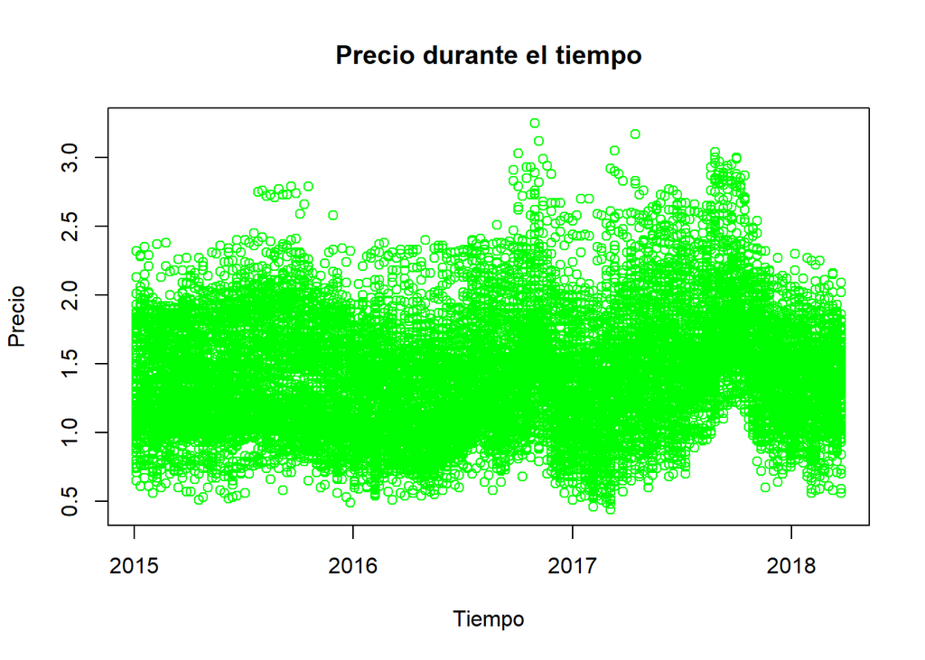

```r
plot(data$Date, data$AveragePrice, col = "green", main = "Precio durante el tiempo", xlab = "Tiempo", ylab = "Precio")
```

En este sentido se observa ciertas correlaciones respecto el precio de los aguacates y en la fecha, donde se puede observar una subida del precio en algunas temporadas a finales de anio.

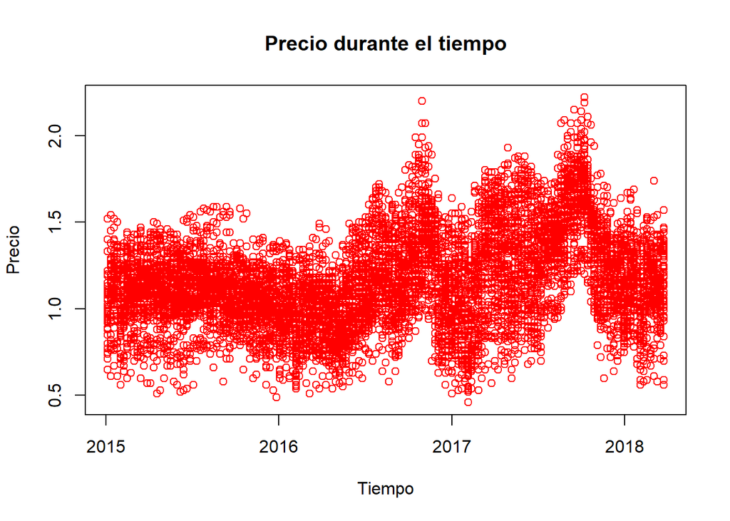

```r
plot(data$Date[data$type=="conventional"], data$AveragePrice[data$type=="conventional"] , col = "red", main = "Precio durante el tiempo", xlab = "Tiempo", ylab = "Precio")
```

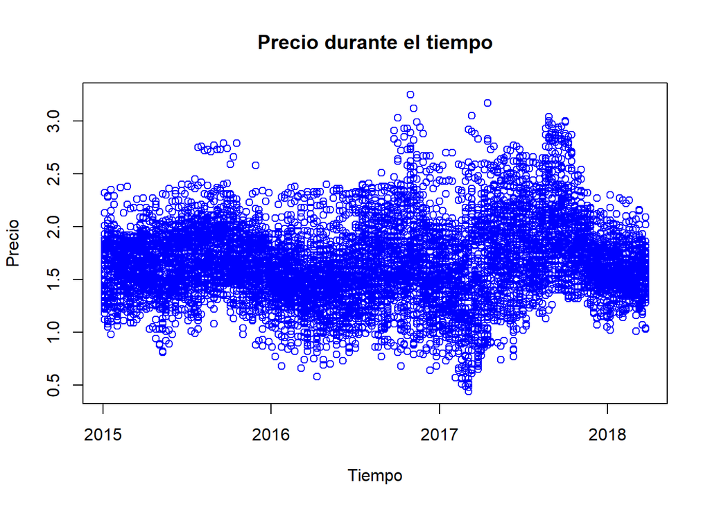

```r
plot(data$Date[data$type=="organic"], data$AveragePrice[data$type=="organic"] , col = "blue", main = "Precio durante el tiempo", xlab = "Tiempo", ylab = "Precio")
```

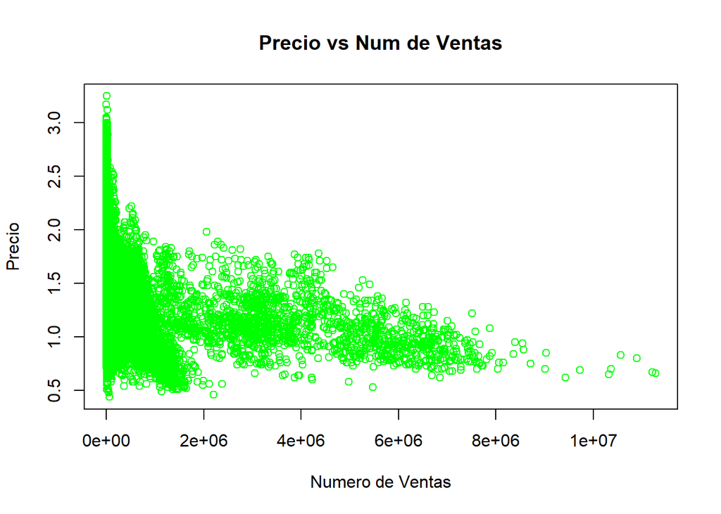

```r
plot(data$Total.Volume, data$AveragePrice , col = "Green", main = "Precio vs Num de Ventas", xlab = "Numero de Ventas", ylab = "Precio")
```

Por otro lado, como era de esperar, a medida que el numero de ventas crece, el precio tiende a estabilizarse y bajar. Siendo en momentos donde las ventas soy muy menores el precio del aguacate, independientemente del tipo es muy dispar.

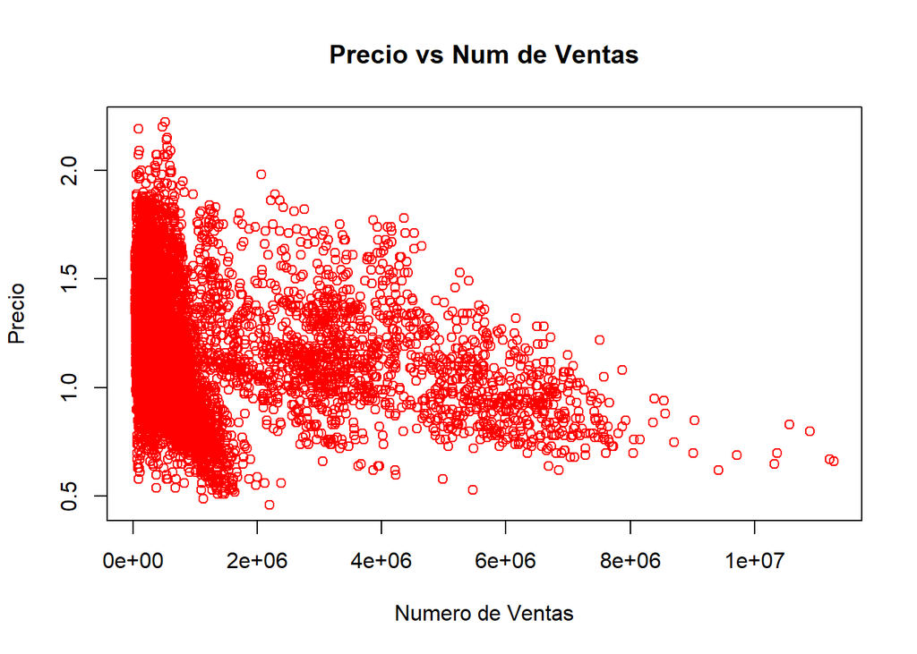

```r
plot(data$Total.Volume[data$type=="conventional"], data$AveragePrice[data$type=="conventional"] , col = "red", main = "Precio vs Num de Ventas", xlab = "Numero de Ventas", ylab = "Precio")
```

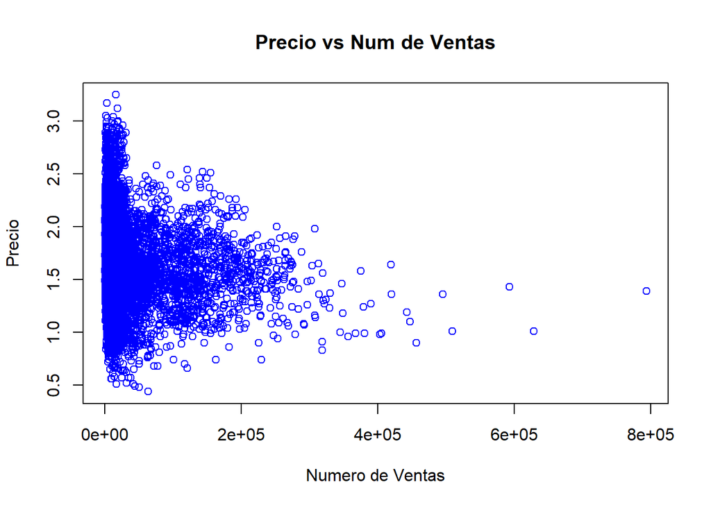

```r
plot(data$Total.Volume[data$type=="organic"], data$AveragePrice[data$type=="organic"] , col = "blue", main = "Precio vs Num de Ventas", xlab = "Numero de Ventas", ylab = "Precio")
```

Se observan diferencias respecto en cuanto las ventas son mayores, en el caso de los orgánicos, este precio tiene a situarse en la mediana, sin embargo, en el caso de los convencionales, este suele situarse en la parte mas baja, dentro del primer cuartil de precio.

```r
cor.test(data$AveragePrice, data$Total.Volume, method= "spearman")
```

```
##
##  Spearman's rank correlation rho
##
## data:  data$AveragePrice and data$Total.Volume
## S = 1.5531e+12, p-value < 2.2e-16
## alternative hypothesis: true rho is not equal to 0
## sample estimates:
##        rho
## -0.6218074
```

Esto se confirma realizadno un test de correlacion, donde nos indica que hay una corelacion negativa de -0.62 entre las dos variables. Esto significa, que a medida que aumenta la variable volumen, el precio medio disminiye.

Esto es igual que lo indicado anteriormente por las imagenes.

#### 1.4.3.3 Modelo de regresión

A continuación, vamos realizar un modelo de regresión y de esta manera observamos los valores que puedan afectar mas al precio de los aguacates.

En un primer momento, se incluyen todas las variables para el cálculo del precio de los aguacates, el cual nos indica que es de un R-squared de un 0.57.

```r
summary(lm(AveragePrice~X4046+X4225+X4770+Small.Bags+Large.Bags+XLarge.Bags+type+Date+region, data= data))
```

```
##
## Call:
## lm(formula = AveragePrice ~ X4046 + X4225 + X4770 + Small.Bags +
##     Large.Bags + XLarge.Bags + type + Date + region, data = data)
##
## Residuals:
##      Min       1Q   Median       3Q      Max
## -1.06351 -0.16025 -0.00681  0.14739  1.48050
##
## Coefficients:
##                             Estimate Std. Error t value Pr(>|t|)
## (Intercept)               -1.576e+00  1.041e-01 -15.135  < 2e-16 ***
## X4046                     -1.463e-08  7.733e-09  -1.892 0.058569 .
## X4225                     -4.380e-08  9.233e-09  -4.744 2.11e-06 ***
## X4770                      1.110e-08  6.596e-08   0.168 0.866320
## Small.Bags                -7.219e-08  1.721e-08  -4.194 2.76e-05 ***
## Large.Bags                -9.974e-08  2.766e-08  -3.606 0.000311 ***
## XLarge.Bags                2.930e-06  3.506e-07   8.356  < 2e-16 ***
## typeorganic                4.666e-01  4.728e-03  98.685  < 2e-16 ***
## Date                       1.706e-04  6.055e-06  28.183  < 2e-16 ***
## regionAtlanta             -2.170e-01  2.038e-02 -10.645  < 2e-16 ***
## regionBaltimoreWashington -1.176e-02  2.042e-02  -0.576 0.564863
## regionBoise               -2.133e-01  2.036e-02 -10.475  < 2e-16 ***
## regionBoston              -1.868e-02  2.040e-02  -0.916 0.359884
## regionBuffaloRochester    -4.283e-02  2.036e-02  -2.104 0.035414 *
## regionCalifornia          -9.897e-02  2.216e-02  -4.465 8.04e-06 ***
## regionCharlotte            4.687e-02  2.037e-02   2.301 0.021404 *
## regionChicago              5.186e-03  2.065e-02   0.251 0.801723
## regionCincinnatiDayton    -3.477e-01  2.039e-02 -17.053  < 2e-16 ***
## regionColumbus            -3.086e-01  2.036e-02 -15.157  < 2e-16 ***
## regionDallasFtWorth       -4.601e-01  2.045e-02 -22.497  < 2e-16 ***
## regionDenver              -3.213e-01  2.057e-02 -15.617  < 2e-16 ***
## regionDetroit             -2.940e-01  2.043e-02 -14.390  < 2e-16 ***
## regionGrandRapids         -6.121e-02  2.037e-02  -3.005 0.002659 **
## regionGreatLakes          -2.020e-01  2.216e-02  -9.114  < 2e-16 ***
## regionHarrisburgScranton  -4.507e-02  2.036e-02  -2.214 0.026830 *
## regionHartfordSpringfield  2.624e-01  2.036e-02  12.888  < 2e-16 ***
## regionHouston             -4.954e-01  2.043e-02 -24.247  < 2e-16 ***
## regionIndianapolis        -2.465e-01  2.036e-02 -12.111  < 2e-16 ***
## regionJacksonville        -4.929e-02  2.036e-02  -2.421 0.015498 *
```

[output cut: 23 more lines]

```
## regionSouthCarolina       -1.546e-01  2.036e-02  -7.592 3.30e-14 ***
## regionSouthCentral        -3.806e-01  2.227e-02 -17.091  < 2e-16 ***
## regionSoutheast           -1.162e-01  2.148e-02  -5.412 6.32e-08 ***
## regionSpokane             -1.152e-01  2.036e-02  -5.659 1.55e-08 ***
## regionStLouis             -1.299e-01  2.036e-02  -6.378 1.83e-10 ***
## regionSyracuse            -4.119e-02  2.035e-02  -2.024 0.042997 *
## regionTampa               -1.484e-01  2.037e-02  -7.284 3.39e-13 ***
## regionWest                -1.524e-01  2.286e-02  -6.669 2.66e-11 ***
## regionWestTexNewMexico    -2.864e-01  2.047e-02 -13.996  < 2e-16 ***
## ---
## Signif. codes:  0 '***' 0.001 '**' 0.01 '*' 0.05 '.' 0.1 ' ' 1
##
## Residual standard error: 0.2646 on 17850 degrees of freedom
## Multiple R-squared:  0.5731, Adjusted R-squared:  0.5716
## F-statistic: 399.3 on 60 and 17850 DF,  p-value: < 2.2e-16
```

Este valor es un poco pobre, debido a que con todas las variable indicadas en este dataset no permitiría predecir cual sería el precio aproximado según sus características. Realizaremos una comprobación en la cual se podra observar si hay alguna variable que genera “ruido” y que nos permita aumentar su fiabilidad:

```r
summary(lm(AveragePrice~type+X4046+X4225+X4770+region, data= data))
```

```
##
## Call:
## lm(formula = AveragePrice ~ type + X4046 + X4225 + X4770 + region,
##     data = data)
##
## Residuals:
##      Min       1Q   Median       3Q      Max
## -1.08502 -0.16910 -0.01722  0.14505  1.52345
##
## Coefficients:
##                             Estimate Std. Error t value Pr(>|t|)
## (Intercept)                1.331e+00  1.498e-02  88.839  < 2e-16 ***
## typeorganic                4.651e-01  4.824e-03  96.404  < 2e-16 ***
## X4046                     -3.000e-08  6.822e-09  -4.398 1.10e-05 ***
## X4225                     -6.466e-08  8.513e-09  -7.595 3.23e-14 ***
## X4770                      7.563e-08  6.282e-08   1.204 0.228699
## regionAtlanta             -2.192e-01  2.091e-02 -10.482  < 2e-16 ***
## regionBaltimoreWashington -1.325e-02  2.094e-02  -0.633 0.526966
## regionBoise               -2.148e-01  2.089e-02 -10.282  < 2e-16 ***
## regionBoston              -1.900e-02  2.093e-02  -0.908 0.364068
## regionBuffaloRochester    -4.459e-02  2.088e-02  -2.135 0.032787 *
## regionCalifornia          -7.266e-02  2.233e-02  -3.253 0.001143 **
## regionCharlotte            4.469e-02  2.090e-02   2.139 0.032486 *
## regionChicago              6.216e-03  2.115e-02   0.294 0.768854
## regionCincinnatiDayton    -3.505e-01  2.089e-02 -16.780  < 2e-16 ***
## regionColumbus            -3.089e-01  2.089e-02 -14.786  < 2e-16 ***
## regionDallasFtWorth       -4.600e-01  2.097e-02 -21.935  < 2e-16 ***
## regionDenver              -3.335e-01  2.090e-02 -15.956  < 2e-16 ***
## regionDetroit             -2.854e-01  2.094e-02 -13.628  < 2e-16 ***
## regionGrandRapids         -5.591e-02  2.089e-02  -2.676 0.007458 **
## regionGreatLakes          -1.767e-01  2.248e-02  -7.862 3.99e-15 ***
## regionHarrisburgScranton  -4.562e-02  2.089e-02  -2.184 0.028963 *
## regionHartfordSpringfield  2.624e-01  2.089e-02  12.561  < 2e-16 ***
## regionHouston             -4.988e-01  2.096e-02 -23.802  < 2e-16 ***
## regionIndianapolis        -2.468e-01  2.089e-02 -11.819  < 2e-16 ***
## regionJacksonville        -5.053e-02  2.089e-02  -2.419 0.015573 *
## regionLasVegas            -1.782e-01  2.089e-02  -8.529  < 2e-16 ***
## regionLosAngeles          -3.111e-01  2.125e-02 -14.642  < 2e-16 ***
## regionLouisville          -2.752e-01  2.089e-02 -13.178  < 2e-16 ***
## regionMiamiFtLauderdale   -1.269e-01  2.092e-02  -6.069 1.31e-09 ***
```

[output cut: 19 more lines]

```
## regionSouthCarolina       -1.556e-01  2.089e-02  -7.449 9.82e-14 ***
## regionSouthCentral        -3.776e-01  2.281e-02 -16.555  < 2e-16 ***
## regionSoutheast           -1.187e-01  2.178e-02  -5.448 5.15e-08 ***
## regionSpokane             -1.167e-01  2.089e-02  -5.586 2.36e-08 ***
## regionStLouis             -1.310e-01  2.089e-02  -6.270 3.70e-10 ***
## regionSyracuse            -4.194e-02  2.089e-02  -2.008 0.044652 *
## regionTampa               -1.494e-01  2.090e-02  -7.151 8.92e-13 ***
## regionWest                -2.029e-01  2.213e-02  -9.169  < 2e-16 ***
## regionWestTexNewMexico    -2.886e-01  2.099e-02 -13.748  < 2e-16 ***
## ---
## Signif. codes:  0 '***' 0.001 '**' 0.01 '*' 0.05 '.' 0.1 ' ' 1
##
## Residual standard error: 0.2715 on 17854 degrees of freedom
## Multiple R-squared:  0.5503, Adjusted R-squared:  0.5489
## F-statistic: 390.2 on 56 and 17854 DF,  p-value: < 2.2e-16
```

## 1.5 Representación de los resultados a partir de tablas y gráficas.

A lo largo de los apartados anteriores se han realizado gráficas y tablas para acompañar y complementar las explicaciones. Además, a continuación se añadirán varias gráficas para observar algunos comportamientos y relaciones.

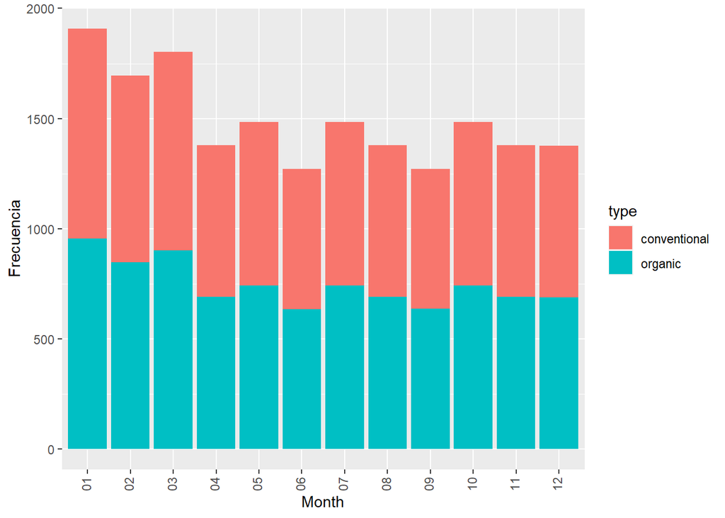

```r
multihisto <- ggplot(data = data,aes(x=Month,fill=type))+geom_bar()+ylab("Frecuencia")
multihisto + theme(axis.text.x = element_text(angle = 90, hjust = 1, vjust=0.3))
```

Si queremos ver para cada mes cual es el porcentaje de aguacates convencionales y orgánicos vendidos podemos mostrar el gráfica anterior de manera porcentual. A continuación, se puede observar el gráfico y se puede apreciar que la mitad de las ventas de cada mes se corresponden con el tipo orgánico y la otra mitad con el tipo convencional.

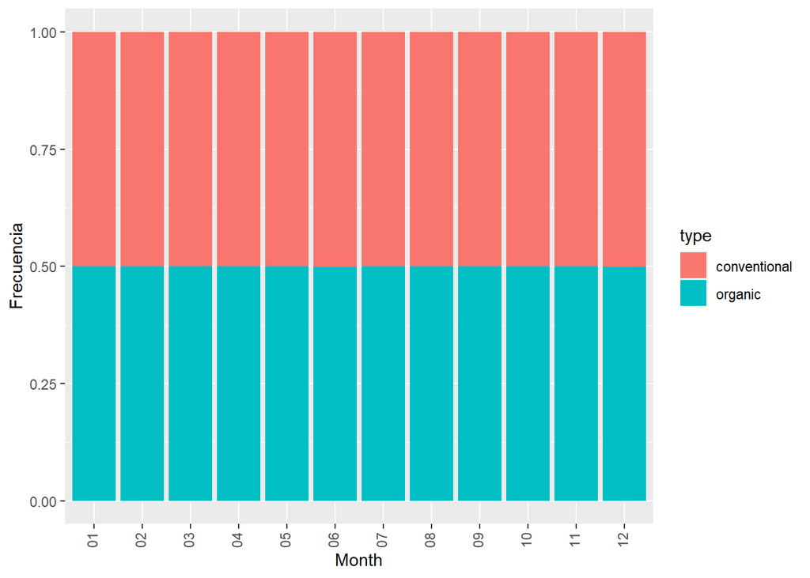

```r
multihisto <- ggplot(data = data,aes(x=Month,fill=type))+geom_bar(position = 'fill')+ylab("Frecuencia")
multihisto + theme(axis.text.x = element_text(angle = 90, hjust = 1, vjust=0.3))
```